# My Assignment 2 Title (How tax and location and list price affect sold price in Toronto)

zhixin zhu 1004724391

October 24, 2020

```r
knitr::opts_chunk$set(echo = F, message =  F, warning = F)
library(knitr)
library(tidyverse)
```

## I. Introduction

The title fo this analysis is:“How tax and location and list price affect sold price in Toronto.” This analysis is used for study how those three element influence the property price in Toronto, and also, does it exist any linear relationship between them.

```
##    ID  sold   list taxes location
## 1 133 1.140 1.1990  5778        M
## 2 143 1.155 1.1648  5981        M
## 3 101 1.300 1.2980  4592        T
## 4  29 3.650 3.8500 15077        T
## 5 192 1.160 1.1900  5105        M
## 6 221 1.410 1.4690  6083        M
```

## II. Exploratory Data Analysis’

Firstly, I analyzed the data that we have collect. In order to check whether it exist outlier in this data, I make the following scatterplot graph.

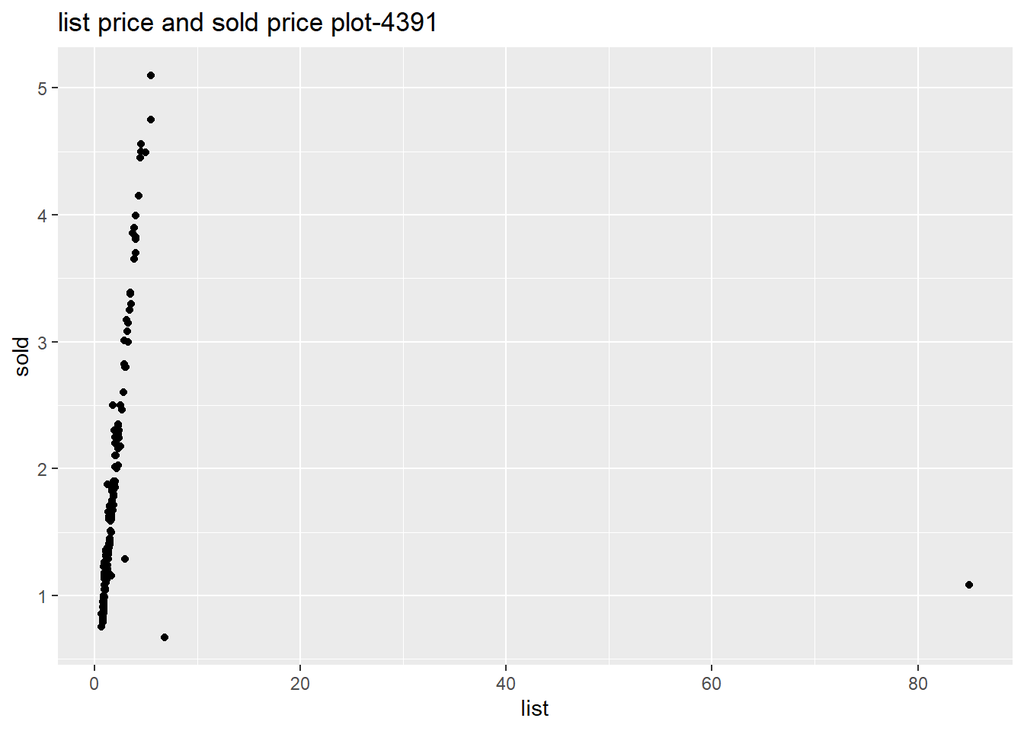

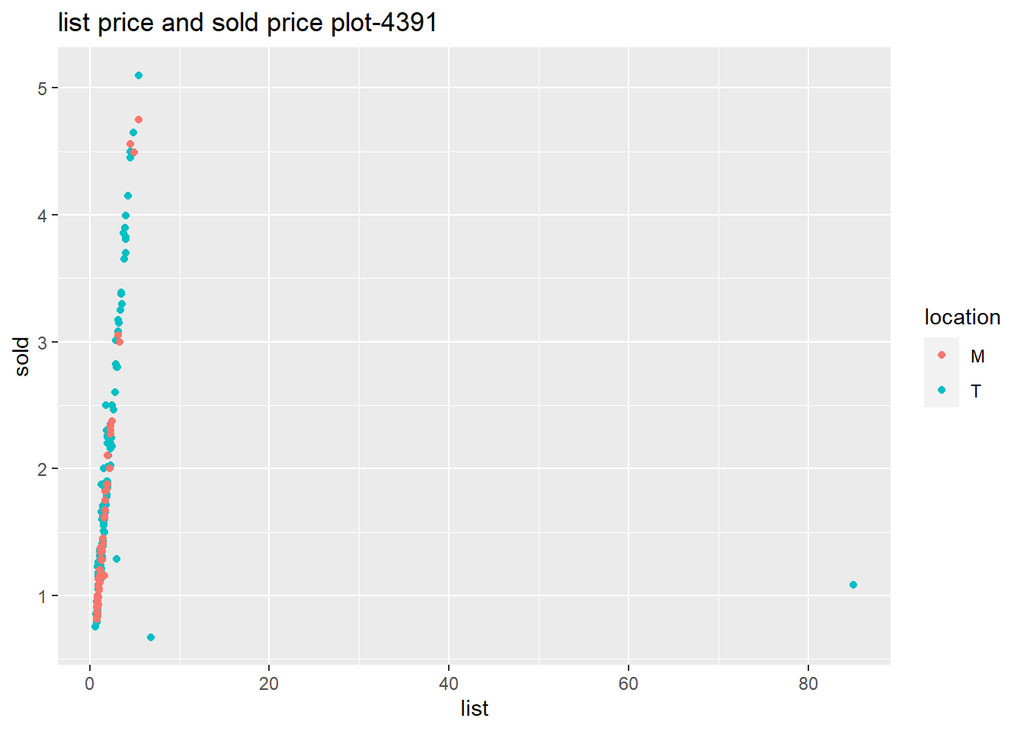

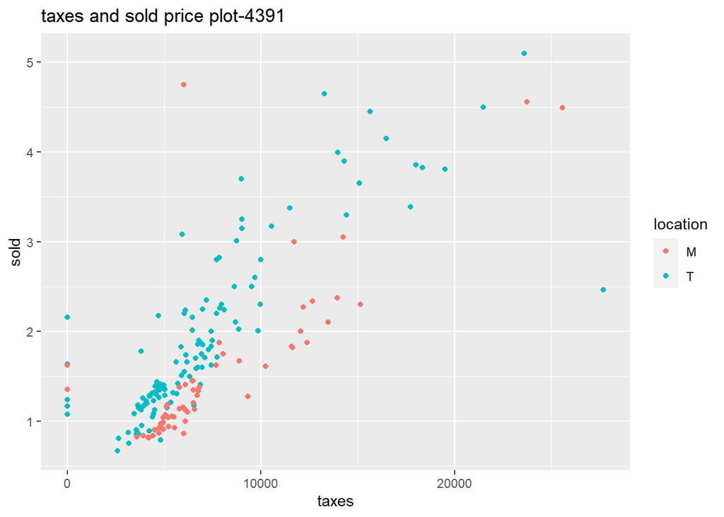

In taxes and sold price plot-4391, we see a moderately strong linear relationship between property tax and sale price, and taxes are roughly similar in Toronto and Missisauga.

## III. Methods and Model

model 1

```
##
## Call:
## lm(formula = sold ~ list, data = data2)
##
## Residuals:
##     Min      1Q  Median      3Q     Max
## -2.3761 -0.6095 -0.3308  0.3500  3.2731
##
## Coefficients:
##             Estimate Std. Error t value Pr(>|t|)
## (Intercept)  1.71391    0.06527  26.260   <2e-16 ***
## list         0.02056    0.01091   1.883   0.0609 .
## ---
## Signif. codes:  0 '***' 0.001 '**' 0.01 '*' 0.05 '.' 0.1 ' ' 1
##
## Residual standard error: 0.9226 on 228 degrees of freedom
## Multiple R-squared:  0.01532,    Adjusted R-squared:  0.011
## F-statistic: 3.547 on 1 and 228 DF,  p-value: 0.06092
```

```
##                     2.5 %   97.5 %
## (Intercept)  1.5853030296 1.842512
## list        -0.0009496602 0.042064
```

Summary how list price correlated with sold price-4391

|  | Estimate | Std. Error | t value | Pr(>\|t\|) |
| --- | --- | --- | --- | --- |
| (Intercept) | 1.714 | 0.065 | 26.260 | 0.000 |
| list | 0.021 | 0.011 | 1.883 | 0.061 |

```
##
## Call:
## lm(formula = sold ~ list, data = data[data2$location == "T",
##     ])
##
## Residuals:
##      Min       1Q   Median       3Q      Max
## -0.45702 -0.06947 -0.03423  0.04644  0.71334
##
## Coefficients:
##             Estimate Std. Error t value Pr(>|t|)
## (Intercept)  0.12274    0.02467   4.975 2.06e-06 ***
## list         0.92458    0.01214  76.147  < 2e-16 ***
## ---
## Signif. codes:  0 '***' 0.001 '**' 0.01 '*' 0.05 '.' 0.1 ' ' 1
##
## Residual standard error: 0.1306 on 128 degrees of freedom
## Multiple R-squared:  0.9784, Adjusted R-squared:  0.9782
## F-statistic:  5798 on 1 and 128 DF,  p-value: < 2.2e-16
```

```
##                  2.5 %    97.5 %
## (Intercept) 0.07391662 0.1715560
## list        0.90055851 0.9486091
```

Summary how list price correlated with sold price in Toronto-4391

|  | Estimate | Std. Error | t value | Pr(>\|t\|) |
| --- | --- | --- | --- | --- |
| (Intercept) | 0.123 | 0.025 | 4.975 | 0 |
| list | 0.925 | 0.012 | 76.147 | 0 |

```
##
## Call:
## lm(formula = sold ~ list, data = data[data2$location == "M",
##     ])
##
## Residuals:
##     Min      1Q  Median      3Q     Max
## -1.1052 -0.6977 -0.4086  0.3935  3.3267
##
## Coefficients:
##             Estimate Std. Error t value Pr(>|t|)
## (Intercept) 1.756955   0.134241  13.088   <2e-16 ***
## list        0.002973   0.012892   0.231    0.818
## ---
## Signif. codes:  0 '***' 0.001 '**' 0.01 '*' 0.05 '.' 0.1 ' ' 1
##
## Residual standard error: 1.073 on 68 degrees of freedom
##   (30 observations deleted due to missingness)
## Multiple R-squared:  0.0007817,  Adjusted R-squared:  -0.01391
## F-statistic: 0.0532 on 1 and 68 DF,  p-value: 0.8183
```

```
##                  2.5 %     97.5 %
## (Intercept)  1.4890814 2.02482796
## list        -0.0227514 0.02869828
```

Summary how list price correlated with sold price in Missisauga-4391

[output not shown]

Since for the summary of model1 and model3 for this part, the R-squared value is not close to 1, those two model are not appropriate, In the model 2, which R-squared is 0.9784, this means that sold price more fit the model.

## IV. Discussions and Limitations

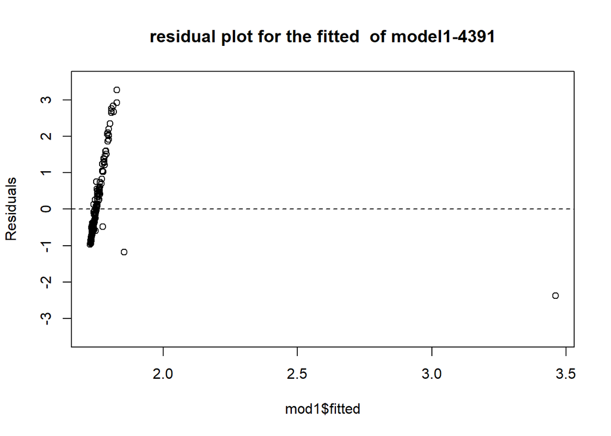

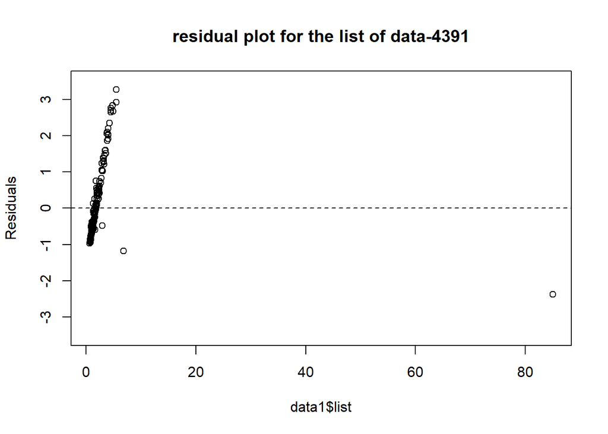

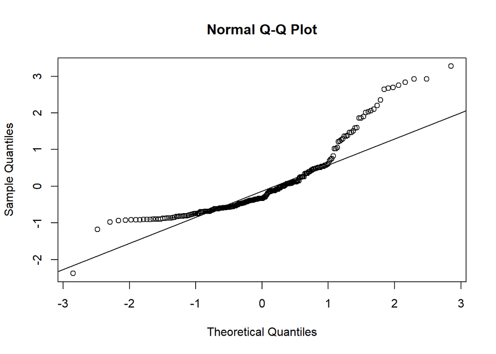

Except the factor we consider in this analysis, some other element may influence the property price in Toronto, such as economy and immigration. More immigration may increase the demand for house price in a certain region, which may increase the sold price. Besides, the economy will also influence the property price, because economy will influence the purchase power, and influence the property price further.